# NF05 · Collisions ("bumper cars"): does contact redirect cells?

Cellpose partitions the pixel grid, so adjacent cells' polygons genuinely **touch** (zero-area boundary contact) rather than needing an arbitrary distance threshold — the literal "bumper cars" collision event. This notebook counts every such contact across the live movie (all detected cells, not just tracked/linked ones), then asks the classic **contact inhibition of locomotion** question: does a cell change heading more sharply right after touching a neighbor than it does at a random moment?

## 1 · Collision count, all detected cells, all live frames

```
96,408 total collision (contact) events across 60 live frames
```

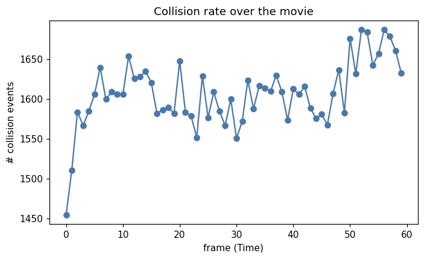

## 2 · Do cells turn more sharply right after a collision?

```
86,641 distinct (trajectory, frame) collision participations
collision moments: n=82,133, median |turn|=112.8 deg
non-collision moments: n=100,473, median |turn|=111.6 deg
Mann-Whitney U (collided > control): U=4177466310, p=2.26e-06
```

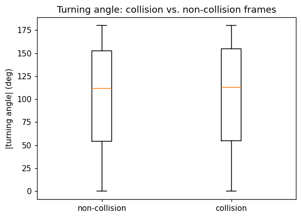

## 3 · Collision rate vs. time (density context) and per-cell collision count vs. morphology/CP

```
n_collisions vs. LCI shape-over-time features (all live trajectories):
```

|  | feature | rho | p |
| --- | --- | --- | --- |
| 0 | area_mean | 0.184488 | 8.515860e-35 |
| 2 | perimeter_mean | 0.183974 | 1.310572e-34 |
| 8 | equivalent_diameter_mean | 0.183528 | 1.902668e-34 |
| 7 | elongation_cv | 0.167238 | 6.211724e-28 |
| 3 | perimeter_cv | 0.142216 | 1.425073e-20 |
| 4 | solidity_mean | -0.136216 | 1.436563e-19 |
| 5 | solidity_cv | 0.134500 | 1.506579e-18 |
| 10 | form_factor_mean | -0.098008 | 8.227222e-11 |
| 1 | area_cv | 0.098853 | 1.147190e-10 |
| 11 | form_factor_cv | 0.096145 | 3.639254e-10 |

```
n_collisions vs. CP morphology (2,130 linked cells):
```

|  | cp_feature | rho | p |
| --- | --- | --- | --- |
| 60 | Intensity_MeanIntensityEdge_OrigActin_Golgi_Me... | 0.162542 | 4.438199e-14 |
| 85 | Intensity_StdIntensityEdge_OrigActin_Golgi_Mem... | 0.158044 | 2.202707e-13 |
| 50 | Intensity_MaxIntensityEdge_OrigActin_Golgi_Mem... | 0.153157 | 1.191898e-12 |
| 61 | Intensity_MeanIntensityEdge_OrigDNA | 0.147978 | 6.729138e-12 |
| 51 | Intensity_MaxIntensityEdge_OrigDNA | 0.145910 | 1.320938e-11 |
| 76 | Intensity_MinIntensityEdge_OrigDNA | 0.143134 | 3.218226e-11 |
| 143 | RadialDistribution_RadialCV_OrigActin_Golgi_Me... | 0.140812 | 6.689030e-11 |
| 81 | Intensity_MinIntensity_OrigDNA | 0.138635 | 1.313835e-10 |
| 26 | Intensity_IntegratedIntensityEdge_OrigDNA | 0.130497 | 1.494063e-09 |
| 35 | Intensity_LowerQuartileIntensity_OrigActin_Gol... | 0.108276 | 5.472850e-07 |

## ⭐ Key finding

*(Corrected: an earlier pass accidentally included post-fixation frames in the turning-angle and shape/collision-count analyses -- now explicitly filtered to `frame_index <= MOTILITY_LAST_FRAME`. Also fixed a missing `nan_policy="omit"` -- single-frame trajectories give NaN coefficient-of-variation, which silently NaN'd whole Spearman correlations without it.)*

**96,408 genuine polygon-contact collisions** across the 60 live frames (all detected cells, not just tracked/linked ones) — cells touch neighbors constantly in this dense monolayer.

**Weak evidence for contact-inhibition-of-locomotion:** across 82,133 collision moments vs. 100,473 non-collision moments, median |turning angle| is slightly higher right after a collision (112.8° vs. 111.6°, Mann-Whitney p=2.3e-06). Statistically robust given the large n, but the *effect size is small* against an already very noisy single-step baseline (median turn ~112° either way — frame-to-frame tracking is inherently jittery at this spatial scale, per NF01). So: collisions nudge cells to turn slightly more, but this is not a dramatic bounce-off effect.

**Collision count correlates with irregular morphology:** cells with more lifetime collisions have larger, more size-variable shape (`area_mean` ρ=+0.18, `elongation_cv` ρ=+0.17, both p<1e-27, n=4,375) and are less solid/convex (`solidity_mean` ρ=−0.14) — consistent with NF03's crowding-slows-speed finding and NF02's shape-variability-tracks-speed finding: frequently- colliding cells look like the same "protrusive/irregular" phenotype already implicated in slower, more crowded regions. On the CP side (2,130 linked cells), collision count correlates most with **edge-intensity** features (`Intensity_Mean/MaxIntensityEdge_OrigActin_Golgi_Membrane`, ρ≈0.15-0.16) — plausibly the same irregular-boundary signature showing up in the fixed CP image.

**Caveat:** collision detection depends on segmentation boundary precision -- boundary jitter (see NF01's noise-floor check) could create spurious touching/separating events between frames without any real change in physical contact, inflating or deflating collision counts independent of true "bumper cars" behavior. Not yet quantified here.